# **“5조 (달팽이조) 과제”**

# 조원: 이은혜, 정희택, 김 송, 서석정

## **문제 1: 약수와 소수 구하기**

### **1. n이 입력값으로 주어질 때 약수의 개수를 출력하는 함수를 완성하시오.**

```r
div_count <- function (n) return (sum(n %% (1:n)==0))

div_count(100)
```

```
## [1] 9
```

```r
div_count(24)
```

```
## [1] 8
```

```r
div_count(6)
```

```
## [1] 4
```

### **2. n이 입력값으로 주어질 때 소수의 개수를 출력하는 함수를 완성하시오.**

```r
prime_count <- function (n) return(sum(sapply(c(1:n), div_count)==2))

prime_count(10)
```

```
## [1] 4
```

```r
prime_count(100)
```

```
## [1] 25
```

```r
prime_count(1000)
```

```
## [1] 168
```

## **문제 2: mtcars 데이터셋**

### **1. mtcars 데이터셋의 구조를 확인하시오. str(mtcars)**

```r
str(mtcars)
```

```
## 'data.frame':    32 obs. of  11 variables:
##  $ mpg : num  21 21 22.8 21.4 18.7 18.1 14.3 24.4 22.8 19.2 ...
##  $ cyl : num  6 6 4 6 8 6 8 4 4 6 ...
##  $ disp: num  160 160 108 258 360 ...
##  $ hp  : num  110 110 93 110 175 105 245 62 95 123 ...
##  $ drat: num  3.9 3.9 3.85 3.08 3.15 2.76 3.21 3.69 3.92 3.92 ...
##  $ wt  : num  2.62 2.88 2.32 3.21 3.44 ...
##  $ qsec: num  16.5 17 18.6 19.4 17 ...
##  $ vs  : num  0 0 1 1 0 1 0 1 1 1 ...
##  $ am  : num  1 1 1 0 0 0 0 0 0 0 ...
##  $ gear: num  4 4 4 3 3 3 3 4 4 4 ...
##  $ carb: num  4 4 1 1 2 1 4 2 2 4 ...
```

### **2. mtcars 데이터셋의 요약정보를 확인하시오.**

```r
summary(mtcars)
```

```
##       mpg             cyl             disp             hp
##  Min.   :10.40   Min.   :4.000   Min.   : 71.1   Min.   : 52.0
##  1st Qu.:15.43   1st Qu.:4.000   1st Qu.:120.8   1st Qu.: 96.5
##  Median :19.20   Median :6.000   Median :196.3   Median :123.0
##  Mean   :20.09   Mean   :6.188   Mean   :230.7   Mean   :146.7
##  3rd Qu.:22.80   3rd Qu.:8.000   3rd Qu.:326.0   3rd Qu.:180.0
##  Max.   :33.90   Max.   :8.000   Max.   :472.0   Max.   :335.0
##       drat             wt             qsec             vs
##  Min.   :2.760   Min.   :1.513   Min.   :14.50   Min.   :0.0000
##  1st Qu.:3.080   1st Qu.:2.581   1st Qu.:16.89   1st Qu.:0.0000
##  Median :3.695   Median :3.325   Median :17.71   Median :0.0000
##  Mean   :3.597   Mean   :3.217   Mean   :17.85   Mean   :0.4375
##  3rd Qu.:3.920   3rd Qu.:3.610   3rd Qu.:18.90   3rd Qu.:1.0000
##  Max.   :4.930   Max.   :5.424   Max.   :22.90   Max.   :1.0000
##        am              gear            carb
##  Min.   :0.0000   Min.   :3.000   Min.   :1.000
##  1st Qu.:0.0000   1st Qu.:3.000   1st Qu.:2.000
##  Median :0.0000   Median :4.000   Median :2.000
##  Mean   :0.4062   Mean   :3.688   Mean   :2.812
##  3rd Qu.:1.0000   3rd Qu.:4.000   3rd Qu.:4.000
##  Max.   :1.0000   Max.   :5.000   Max.   :8.000
```

### **3. gear의 개수가 4인 자동차 모델의 모든 열 정보를 추출하시오.**

```r
mtcars[mtcars$gear==4,]
```

```
##                 mpg cyl  disp  hp drat    wt  qsec vs am gear carb
## Mazda RX4      21.0   6 160.0 110 3.90 2.620 16.46  0  1    4    4
## Mazda RX4 Wag  21.0   6 160.0 110 3.90 2.875 17.02  0  1    4    4
## Datsun 710     22.8   4 108.0  93 3.85 2.320 18.61  1  1    4    1
## Merc 240D      24.4   4 146.7  62 3.69 3.190 20.00  1  0    4    2
## Merc 230       22.8   4 140.8  95 3.92 3.150 22.90  1  0    4    2
## Merc 280       19.2   6 167.6 123 3.92 3.440 18.30  1  0    4    4
## Merc 280C      17.8   6 167.6 123 3.92 3.440 18.90  1  0    4    4
## Fiat 128       32.4   4  78.7  66 4.08 2.200 19.47  1  1    4    1
## Honda Civic    30.4   4  75.7  52 4.93 1.615 18.52  1  1    4    2
## Toyota Corolla 33.9   4  71.1  65 4.22 1.835 19.90  1  1    4    1
## Fiat X1-9      27.3   4  79.0  66 4.08 1.935 18.90  1  1    4    1
## Volvo 142E     21.4   4 121.0 109 4.11 2.780 18.60  1  1    4    2
```

### **4. gear의 개수가 4인 자동차 모델의 mpg, cyl, hp, wt 열 정보만 추출하시오.**

```r
mtcars[mtcars$gear==4,c('mpg', 'cyl', 'hp', 'wt')]
```

```
##                 mpg cyl  hp    wt
## Mazda RX4      21.0   6 110 2.620
## Mazda RX4 Wag  21.0   6 110 2.875
## Datsun 710     22.8   4  93 2.320
## Merc 240D      24.4   4  62 3.190
## Merc 230       22.8   4  95 3.150
## Merc 280       19.2   6 123 3.440
## Merc 280C      17.8   6 123 3.440
## Fiat 128       32.4   4  66 2.200
## Honda Civic    30.4   4  52 1.615
## Toyota Corolla 33.9   4  65 1.835
## Fiat X1-9      27.3   4  66 1.935
## Volvo 142E     21.4   4 109 2.780
```

### **5. mpg가 가장 낮은 자동차 모델의 모든 열 정보를 추출하시오.**

```r
mtcars[mtcars$mpg==min(mtcars$mpg), ]
```

```
##                      mpg cyl disp  hp drat    wt  qsec vs am gear carb
## Cadillac Fleetwood  10.4   8  472 205 2.93 5.250 17.98  0  0    3    4
## Lincoln Continental 10.4   8  460 215 3.00 5.424 17.82  0  0    3    4
```

### **6. mpg가 가장 낮은 자동차 모델의 mpg, cyl, hp, wt 열 정보만 추출하시오.**

```r
mtcars[mtcars$mpg==min(mtcars$mpg), c('mpg', 'cyl', 'hp', 'wt')]
```

```
##                      mpg cyl  hp    wt
## Cadillac Fleetwood  10.4   8 205 5.250
## Lincoln Continental 10.4   8 215 5.424
```

### **7. 연비(mpg)의 평균, 분산, 표준편차를 구하시오.**

```r
mean(mtcars$mpg)
```

```
## [1] 20.09062
```

```r
sd(mtcars$mpg)
```

```
## [1] 6.026948
```

```r
var(mtcars$mpg)
```

```
## [1] 36.3241
```

### **8. 연비(mpg)가 중앙값(median)보다 큰 모델들의 평균, 표준편차를 구하시오.**

```r
mean((mtcars[mtcars$mpg>median(mtcars$mpg), 'mpg']))
```

```
## [1] 25.09333
```

```r
sd((mtcars[mtcars$mpg>median(mtcars$mpg), 'mpg']))
```

```
## [1] 4.680883
```

### **9. 연비(mpg)의 히스토그램을 그리시오.**

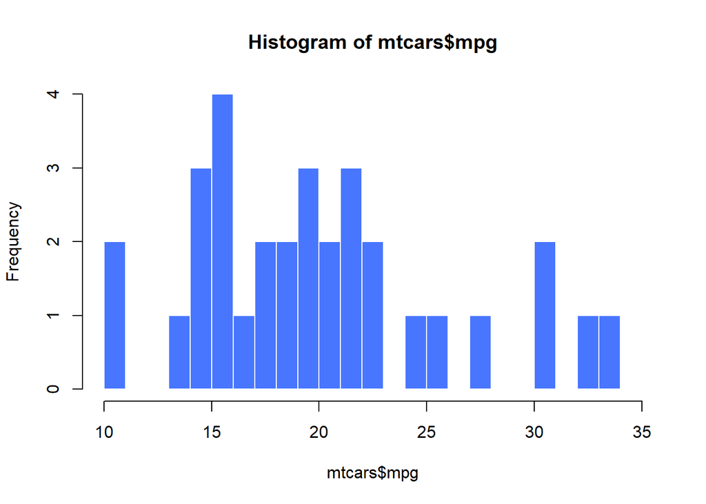

```r
hist(mtcars$mpg,
     breaks = seq(10,35, by=1),
     col='royalblue1',
     border=F)
```

### **10. 기어(gear)의 개수에 따른 빈도수를 나타내는 barplot을 그리시오.**

```r
table(mtcars$gear)
```

```
##
##  3  4  5
## 15 12  5
```

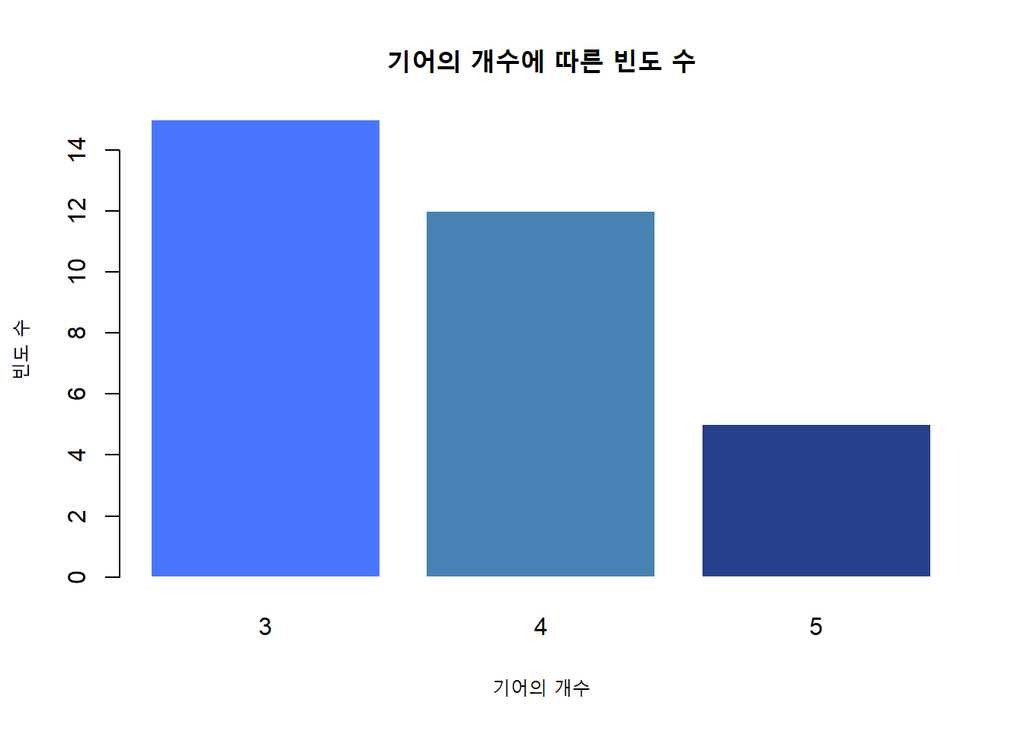

```r
barplot(table(mtcars$gear),
        main='기어의 개수에 따른 빈도 수',
        xlab='기어의 개수',
        ylab='빈도 수',
        col=c('royalblue1', 'steelblue', 'royalblue4'),
        border=F)
```

### **11. mpg와 wt와의 관계를 나타내는 산점도(scatter plot)를 그리시오.**

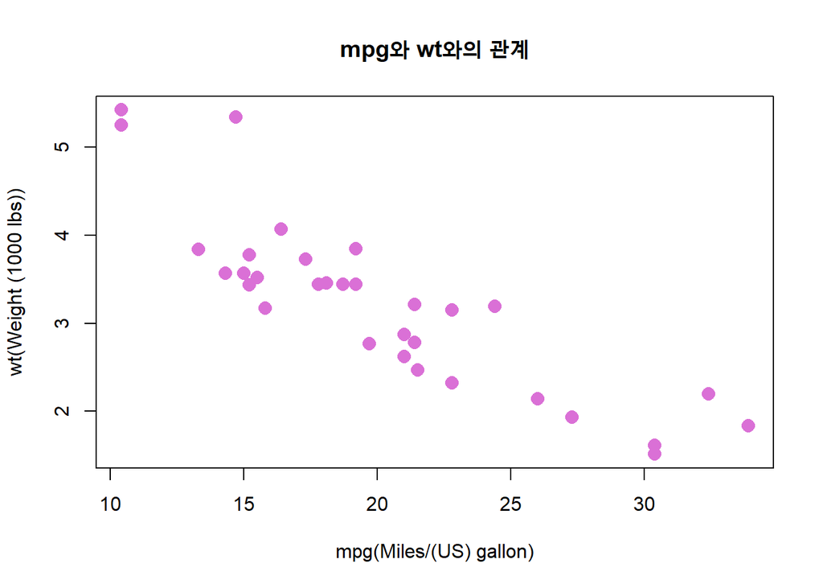

```r
plot(mtcars$mpg, mtcars$wt,
     main='mpg와 wt와의 관계',
     xlab='mpg(Miles/(US) gallon)',
     ylab='wt(Weight (1000 lbs))',
     cex=1.5,
     pch=16,
     col='orchid')
```

## **문제 3: state.x77 데이터셋**

### 1. **state.x77 데이터셋의 각 변수값에 대해 조사하시오.**

```r
# ?state.x77
st <- as.data.frame(state.x77)
str(st)
```

```
## 'data.frame':    50 obs. of  8 variables:
##  $ Population: num  3615 365 2212 2110 21198 ...
##  $ Income    : num  3624 6315 4530 3378 5114 ...
##  $ Illiteracy: num  2.1 1.5 1.8 1.9 1.1 0.7 1.1 0.9 1.3 2 ...
##  $ Life Exp  : num  69 69.3 70.5 70.7 71.7 ...
##  $ Murder    : num  15.1 11.3 7.8 10.1 10.3 6.8 3.1 6.2 10.7 13.9 ...
##  $ HS Grad   : num  41.3 66.7 58.1 39.9 62.6 63.9 56 54.6 52.6 40.6 ...
##  $ Frost     : num  20 152 15 65 20 166 139 103 11 60 ...
##  $ Area      : num  50708 566432 113417 51945 156361 ...
```

```r
cor(st, method='kendall')
```

```
##             Population      Income Illiteracy    Life Exp     Murder    HS Grad
## Population  1.00000000  0.08408163  0.2123063 -0.06865555  0.2364983 -0.2353905
## Income      0.08408163  1.00000000 -0.1970811  0.21904389 -0.1448450  0.3579896
## Illiteracy  0.21230629 -0.19708113  1.0000000 -0.42852098  0.5155359 -0.5047401
## Life Exp   -0.06865555  0.21904389 -0.4285210  1.00000000 -0.5997547  0.3952537
## Murder      0.23649826 -0.14484495  0.5155359 -0.59975465  1.0000000 -0.2884066
## HS Grad    -0.23539045  0.35798964 -0.5047401  0.39525368 -0.2884066  1.0000000
## Frost      -0.30454484  0.13098703 -0.5361059  0.22213145 -0.4136233  0.2926233
## Area       -0.10204082  0.04979592 -0.1784726  0.08173280  0.1072016  0.2958727
##                  Frost        Area
## Population -0.30454484 -0.10204082
## Income      0.13098703  0.04979592
## Illiteracy -0.53610593 -0.17847262
## Life Exp    0.22213145  0.08173280
## Murder     -0.41362334  0.10720163
## HS Grad     0.29262334  0.29587272
## Frost       1.00000000  0.05403215
## Area        0.05403215  1.00000000
```

### 2. **state.x77 데이터셋의 데이터 프레임을 분석하시오.**

```r
str(st)
```

```
## 'data.frame':    50 obs. of  8 variables:
##  $ Population: num  3615 365 2212 2110 21198 ...
##  $ Income    : num  3624 6315 4530 3378 5114 ...
##  $ Illiteracy: num  2.1 1.5 1.8 1.9 1.1 0.7 1.1 0.9 1.3 2 ...
##  $ Life Exp  : num  69 69.3 70.5 70.7 71.7 ...
##  $ Murder    : num  15.1 11.3 7.8 10.1 10.3 6.8 3.1 6.2 10.7 13.9 ...
##  $ HS Grad   : num  41.3 66.7 58.1 39.9 62.6 63.9 56 54.6 52.6 40.6 ...
##  $ Frost     : num  20 152 15 65 20 166 139 103 11 60 ...
##  $ Area      : num  50708 566432 113417 51945 156361 ...
```

```r
head(st)
```

```
##            Population Income Illiteracy Life Exp Murder HS Grad Frost   Area
## Alabama          3615   3624        2.1    69.05   15.1    41.3    20  50708
## Alaska            365   6315        1.5    69.31   11.3    66.7   152 566432
## Arizona          2212   4530        1.8    70.55    7.8    58.1    15 113417
## Arkansas         2110   3378        1.9    70.66   10.1    39.9    65  51945
## California      21198   5114        1.1    71.71   10.3    62.6    20 156361
## Colorado         2541   4884        0.7    72.06    6.8    63.9   166 103766
```

```r
tail(st)
```

```
##               Population Income Illiteracy Life Exp Murder HS Grad Frost  Area
## Vermont              472   3907        0.6    71.64    5.5    57.1   168  9267
## Virginia            4981   4701        1.4    70.08    9.5    47.8    85 39780
## Washington          3559   4864        0.6    71.72    4.3    63.5    32 66570
## West Virginia       1799   3617        1.4    69.48    6.7    41.6   100 24070
## Wisconsin           4589   4468        0.7    72.48    3.0    54.5   149 54464
## Wyoming              376   4566        0.6    70.29    6.9    62.9   173 97203
```

### 3. **state.x77 데이터셋의 각 변수별 기술적 통계량을 분석하시오.**

```r
summary(st)
```

```
##    Population        Income       Illiteracy       Life Exp
##  Min.   :  365   Min.   :3098   Min.   :0.500   Min.   :67.96
##  1st Qu.: 1080   1st Qu.:3993   1st Qu.:0.625   1st Qu.:70.12
##  Median : 2838   Median :4519   Median :0.950   Median :70.67
##  Mean   : 4246   Mean   :4436   Mean   :1.170   Mean   :70.88
##  3rd Qu.: 4968   3rd Qu.:4814   3rd Qu.:1.575   3rd Qu.:71.89
##  Max.   :21198   Max.   :6315   Max.   :2.800   Max.   :73.60
##      Murder          HS Grad          Frost             Area
##  Min.   : 1.400   Min.   :37.80   Min.   :  0.00   Min.   :  1049
##  1st Qu.: 4.350   1st Qu.:48.05   1st Qu.: 66.25   1st Qu.: 36985
##  Median : 6.850   Median :53.25   Median :114.50   Median : 54277
##  Mean   : 7.378   Mean   :53.11   Mean   :104.46   Mean   : 70736
##  3rd Qu.:10.675   3rd Qu.:59.15   3rd Qu.:139.75   3rd Qu.: 81163
##  Max.   :15.100   Max.   :67.30   Max.   :188.00   Max.   :566432
```

### 4. **state.x77 데이터셋의 각 변수별 확률분포를 시각화하시오.**

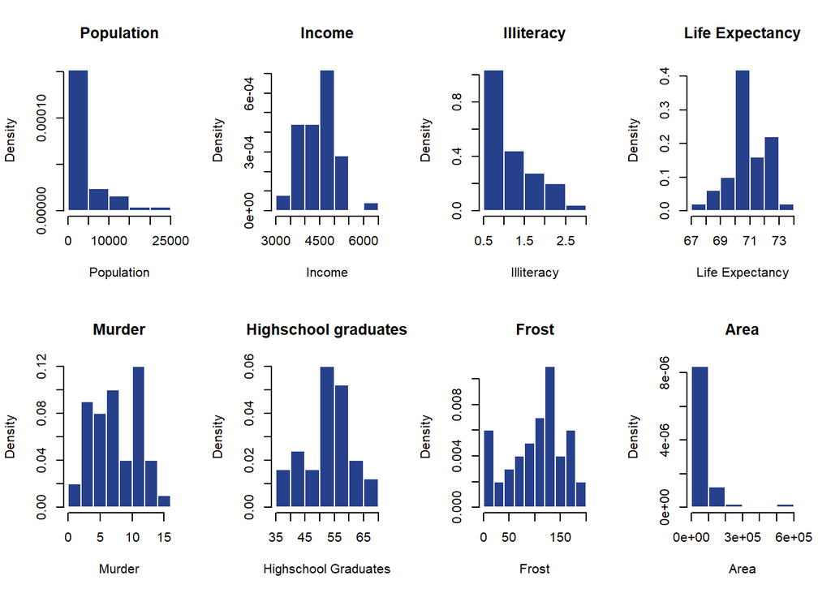

```r
layout(matrix(c(1:8), 2, 4, byrow = TRUE))
hist(st$Population,
     main = "Population",
     col="royalblue4",
     border=F,
     probability=T,
     xlab="Population")
hist(st$Income,
     main = "Income",
     col="royalblue4",
     border=F,
     probability=T,
     xlab="Income")
hist(st$Illiteracy,
     main = "Illiteracy",
     col="royalblue4",
     border=F,
     probability=T,
     xlab="Illiteracy")
hist(st$`Life Exp`,
     main = "Life Expectancy",
     col="royalblue4",
     border=F,
     probability=T,
     xlab="Life Expectancy")
hist(st$Murder,
     main = "Murder",
     col="royalblue4",
     border=F,
     probability=T,
     xlab="Murder")
hist(st$`HS Grad`,
     main = "Highschool graduates",
     col="royalblue4",
     border=F,
     probability=T,
     xlab="Highschool Graduates")
hist(st$Frost,
     main = "Frost",
     col="royalblue4",
     border=F,
     probability=T,
     xlab="Frost")
hist(st$Area,
     main = "Area",
     col="royalblue4",
     border=F,
     probability=T,
     xlab="Area")
```

### 5. **state.x77 데이터셋의 각 변수간의 관계에 대해 분석하고 시각화하시오.**

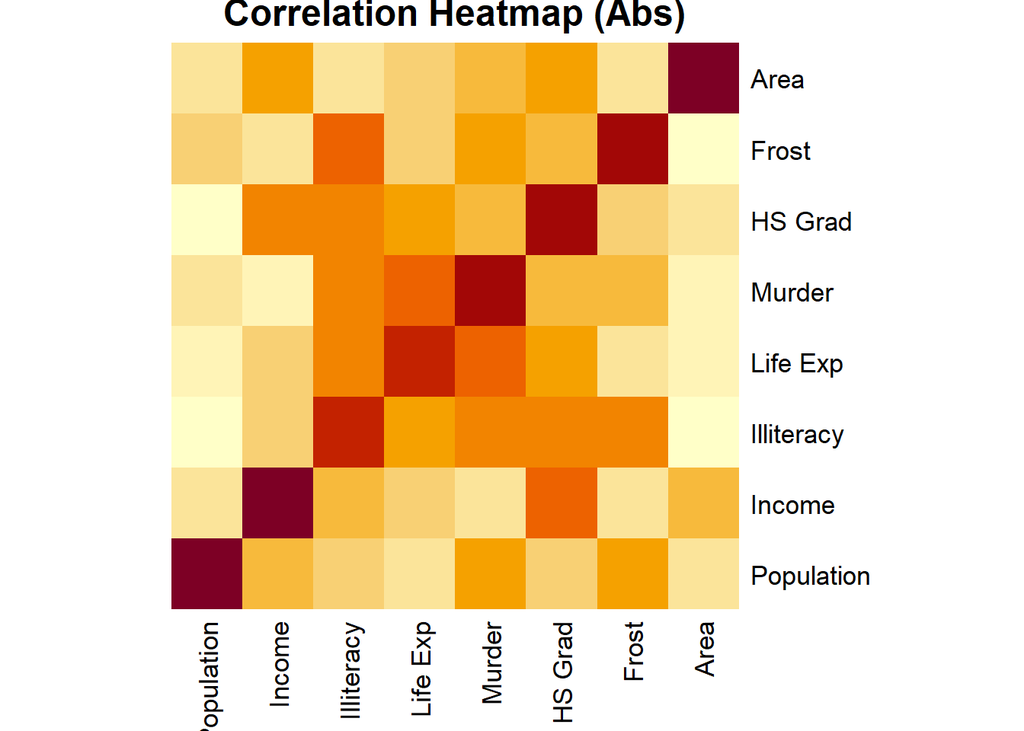

```r
#install.packages('PerformanceAnalytics')
#install.packages('corrplot')

library(PerformanceAnalytics)
library(corrplot)
heatmap(abs(cor(st)),
        main = 'Correlation Heatmap (Abs)',
        Colv = NA,
        Rowv = NA)
```

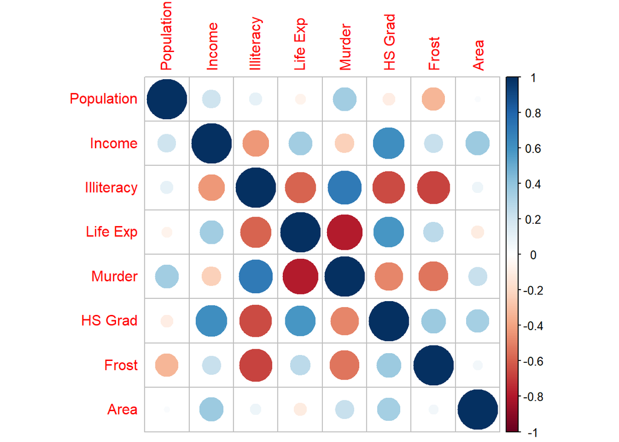

```r
corrplot(x <- cor(st[,1:8]))
```

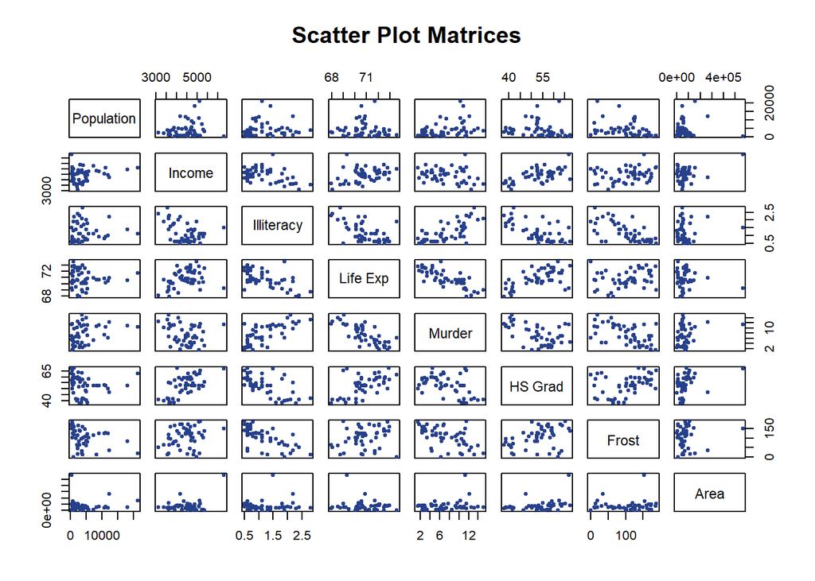

```r
pairs(st[,1:8],
      col='royalblue4',
      pch=20,
      main="Scatter Plot Matrices")
```

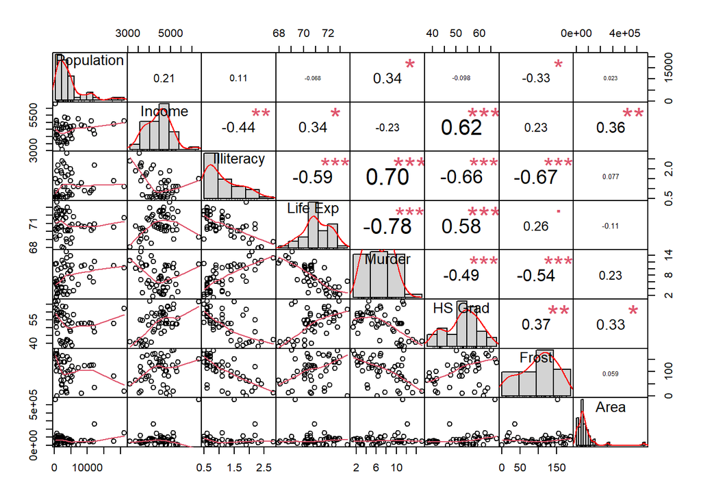

```r
chart.Correlation(st, histogram=, pch='+')
```

```r
#install.packages("psych")

# 상관계수에대한 유의성 검증
with(st, cor.test(`Life Exp`, Murder))     # 2.26e-11
```

```
##
##  Pearson's product-moment correlation
##
## data:  Life Exp and Murder
## t = -8.6596, df = 48, p-value = 2.26e-11
## alternative hypothesis: true correlation is not equal to 0
## 95 percent confidence interval:
##  -0.8700837 -0.6420442
## sample estimates:
##        cor
## -0.7808458
```

```r
with(st, cor.test(`Life Exp`, `HS Grad`))  # 9.196e-06
```

```
##
##  Pearson's product-moment correlation
##
## data:  Life Exp and HS Grad
## t = 4.9613, df = 48, p-value = 9.196e-06
## alternative hypothesis: true correlation is not equal to 0
## 95 percent confidence interval:
##  0.3626369 0.7405513
## sample estimates:
##       cor
## 0.5822162
```

```r
with(st, cor.test(`Life Exp`, Population)) # 0.6387
```

```
##
##  Pearson's product-moment correlation
##
## data:  Life Exp and Population
## t = -0.47257, df = 48, p-value = 0.6387
## alternative hypothesis: true correlation is not equal to 0
## 95 percent confidence interval:
##  -0.3399601  0.2143561
## sample estimates:
##         cor
## -0.06805195
```

```r
library(psych)
print(corr.test(st), short=F)
```

```
## Call:corr.test(x = st)
## Correlation matrix
##            Population Income Illiteracy Life Exp Murder HS Grad Frost  Area
## Population       1.00   0.21       0.11    -0.07   0.34   -0.10 -0.33  0.02
## Income           0.21   1.00      -0.44     0.34  -0.23    0.62  0.23  0.36
## Illiteracy       0.11  -0.44       1.00    -0.59   0.70   -0.66 -0.67  0.08
## Life Exp        -0.07   0.34      -0.59     1.00  -0.78    0.58  0.26 -0.11
## Murder           0.34  -0.23       0.70    -0.78   1.00   -0.49 -0.54  0.23
## HS Grad         -0.10   0.62      -0.66     0.58  -0.49    1.00  0.37  0.33
## Frost           -0.33   0.23      -0.67     0.26  -0.54    0.37  1.00  0.06
## Area             0.02   0.36       0.08    -0.11   0.23    0.33  0.06  1.00
## Sample Size
## [1] 50
## Probability values (Entries above the diagonal are adjusted for multiple tests.)
##            Population Income Illiteracy Life Exp Murder HS Grad Frost Area
## Population       0.00   1.00       1.00     1.00   0.23    1.00  0.25 1.00
## Income           0.15   0.00       0.03     0.23   1.00    0.00  1.00 0.16
## Illiteracy       0.46   0.00       0.00     0.00   0.00    0.00  0.00 1.00
## Life Exp         0.64   0.02       0.00     0.00   0.00    0.00  0.79 1.00
## Murder           0.01   0.11       0.00     0.00   0.00    0.01  0.00 1.00
## HS Grad          0.50   0.00       0.00     0.00   0.00    0.00  0.16 0.25
## Frost            0.02   0.11       0.00     0.07   0.00    0.01  0.00 1.00
## Area             0.88   0.01       0.59     0.46   0.11    0.02  0.68 0.00
##
##  Confidence intervals based upon normal theory.  To get bootstrapped values, try cor.ci
##             raw.lower raw.r raw.upper raw.p lower.adj upper.adj
## Ppltn-Incom     -0.07  0.21      0.46  0.15     -0.19      0.54
## Ppltn-Illtr     -0.18  0.11      0.37  0.46     -0.28      0.46
## Ppltn-LfExp     -0.34 -0.07      0.21  0.64     -0.39      0.27
## Ppltn-Murdr      0.07  0.34      0.57  0.01     -0.07      0.66
## Ppltn-HSGrd     -0.37 -0.10      0.18  0.50     -0.44      0.27
## Ppltn-Frost     -0.56 -0.33     -0.06  0.02     -0.65      0.08
## Ppltn-Area      -0.26  0.02      0.30  0.88     -0.26      0.30
## Incom-Illtr     -0.64 -0.44     -0.18  0.00     -0.72     -0.03
## Incom-LfExp      0.07  0.34      0.57  0.02     -0.07      0.65
## Incom-Murdr     -0.48 -0.23      0.05  0.11     -0.57      0.18
## Incom-HSGrd      0.41  0.62      0.77  0.00      0.27      0.83
## Incom-Frost     -0.06  0.23      0.47  0.11     -0.17      0.56
## Incom-Area       0.09  0.36      0.58  0.01     -0.05      0.67
## Illtr-LfExp     -0.74 -0.59     -0.37  0.00     -0.81     -0.22
## Illtr-Murdr      0.53  0.70      0.82  0.00      0.40      0.87
## Illtr-HSGrd     -0.79 -0.66     -0.46  0.00     -0.85     -0.32
## Illtr-Frost     -0.80 -0.67     -0.48  0.00     -0.85     -0.35
## Illtr-Area      -0.21  0.08      0.35  0.59     -0.28      0.42
## LfExp-Murdr     -0.87 -0.78     -0.64  0.00     -0.91     -0.53
## LfExp-HSGrd      0.36  0.58      0.74  0.00      0.22      0.80
## LfExp-Frost     -0.02  0.26      0.50  0.07     -0.15      0.60
## LfExp-Area      -0.37 -0.11      0.18  0.46     -0.46      0.27
## Murdr-HSGrd     -0.67 -0.49     -0.24  0.00     -0.75     -0.09
## Murdr-Frost     -0.71 -0.54     -0.31  0.00     -0.78     -0.16
## Murdr-Area      -0.05  0.23      0.48  0.11     -0.18      0.57
## HSGrd-Frost      0.10  0.37      0.59  0.01     -0.05      0.68
## HSGrd-Area       0.06  0.33      0.56  0.02     -0.08      0.65
## Frost-Area      -0.22  0.06      0.33  0.68     -0.26      0.37
```

### 6. **state.x77 데이터셋을 대상으로 통계적 분석을 실행하고 통계적 분석을 통해 얻은 분석 결과를 기술하시오.**

#### **분석 0. 변수간 상관관계가 제일 높은 두 변수**

변수간 상관관계가 제일 높은 두 변수는 Life Exp와 Murder로, -0.7808458의 피어슨 상관계수로 강한 음의 상관관계를 가진다.

```r
cor(st$Murder, st$`Life Exp`)
```

```
## [1] -0.7808458
```

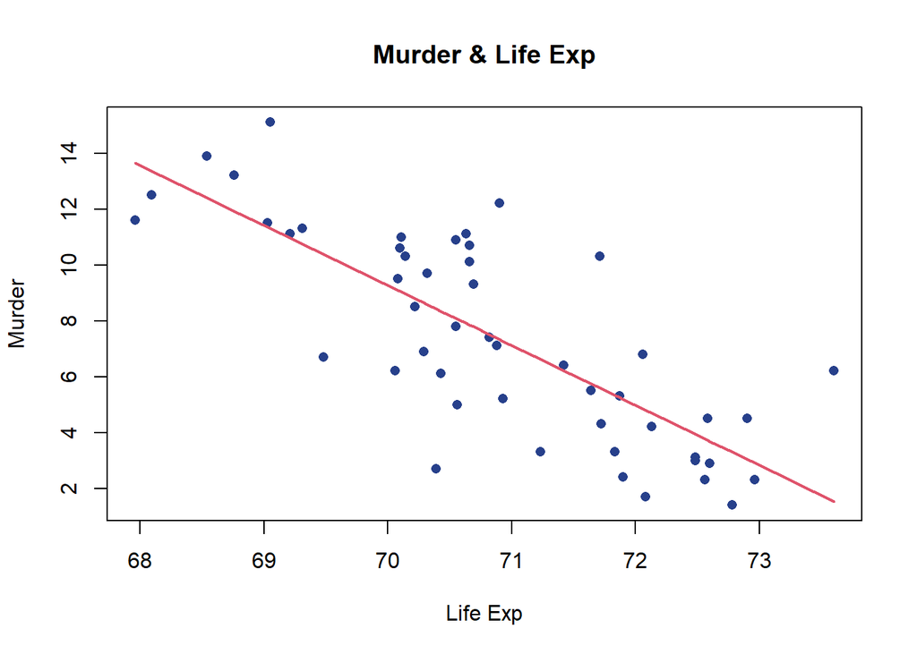

```r
plot(x <- st$`Life Exp`,
     y <- st$Murder,
     pch=16,
     col='royalblue4',
     main='Murder & Life Exp',
     xlab='Life Exp',
     ylab='Murder')
myPredict <- predict( model<- lm(y ~ x) )
ix <- sort(x,index.return=T)$ix
lines(x[ix], myPredict[ix], col=2, lwd=2 )
```

변수간 상관관계가 다음으로 높은 두 변수는 Murder와 Illiteracy로, 0.7029752의 피어슨 상관계수로 뚜렷한 양의 상관관계를 지닌다.

```r
cor(st$Murder, st$Illiteracy)
```

```
## [1] 0.7029752
```

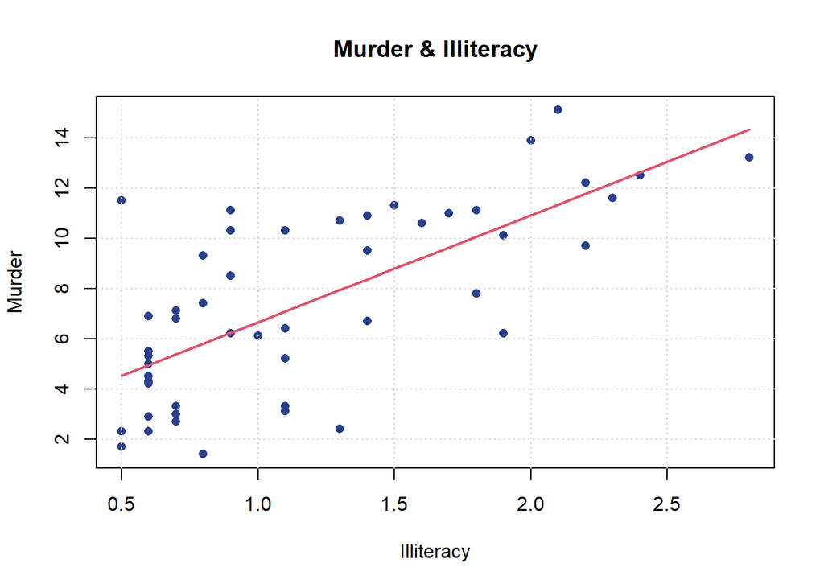

```r
plot(x <- st$Illiteracy,
     y <- st$Murder,
     pch=16,
     col='royalblue4',
     main='Murder & Illiteracy',
     xlab='Illiteracy',
     ylab='Murder')
grid(lwd=1)
myPredict <- predict( model<- lm(y ~ x) )
ix <- sort(x,index.return=T)$ix
lines(x[ix], myPredict[ix], col=2, lwd=2 )
```

#### **분석 1. 상관관계 가정 검토 :두 변수 중 하나는 정규성만족, 두 변수간 선형관계 존재**

```
(1)정규성검정
    Q-Q plot, qqline을 따라 값들이 분포한지 확인
```

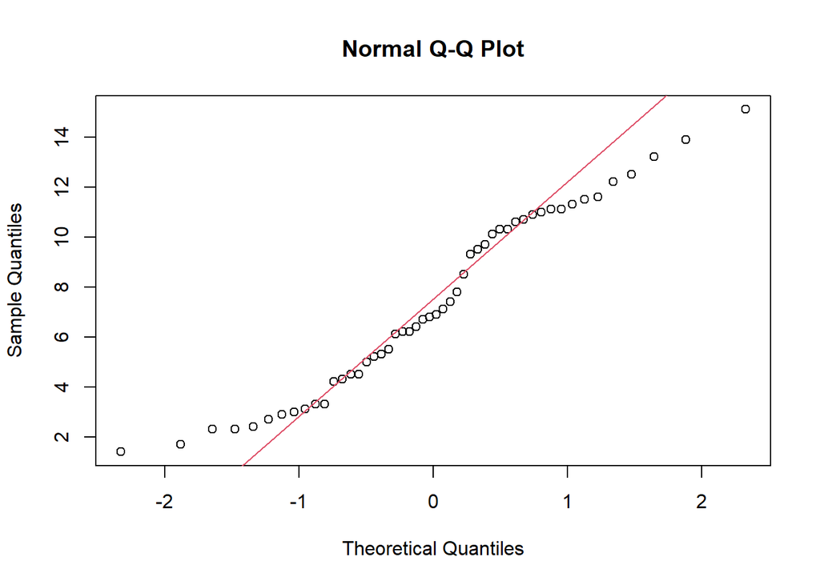

```r
qqnorm(st$Murder)
qqline(st$Murder, col=2)
```

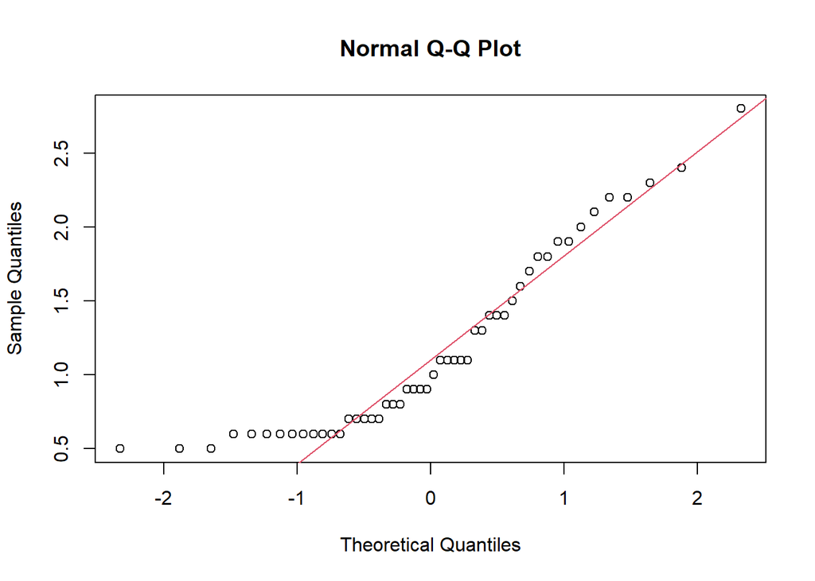

```r
qqnorm(st$Illiteracy)
qqline(st$Illiteracy, col=2)
```

```r
#kolmogorov-Smirnov test
ks.test(st$Murder, 'pnorm', mean=mean(st$Murder), sd=sd(st$Murder))
```

```
##
##  One-sample Kolmogorov-Smirnov test
##
## data:  st$Murder
## D = 0.10955, p-value = 0.5859
## alternative hypothesis: two-sided
```

```r
ks.test(st$Illiteracy, 'pnorm', mean=mean(st$Illiteracy), sd=sd(st$Illiteracy))
```

```
##
##  One-sample Kolmogorov-Smirnov test
##
## data:  st$Illiteracy
## D = 0.1711, p-value = 0.107
## alternative hypothesis: two-sided
```

```
H~0~:정규분포를 따른다
H~1~:정규분포를 따르지 않는다.
Murder와 Illiteracy 모두 p-valu>0.05이므로 귀무가설 채택함.(정규분포를 따른다)

(2) Murder-Illiteracy 상관관계 분석
```

```r
#pearson correlation
cor.test(st$Murder, st$Illiteracy, method='pearson', conf.level = 0.95)
```

```
##
##  Pearson's product-moment correlation
##
## data:  st$Murder and st$Illiteracy
## t = 6.8479, df = 48, p-value = 1.258e-08
## alternative hypothesis: true correlation is not equal to 0
## 95 percent confidence interval:
##  0.5279280 0.8207295
## sample estimates:
##       cor
## 0.7029752
```

```
H~0~:Murder와 Illiteracy는 상관관계가 없다,
H~1~: Murder와 Illiteracy는 상관관계가 있다.
t통계량 6.8479이고 p-value <0.05, α=0.05 미만으로 나타나 귀무가설을 기각한다.
두 변수는 상관계수 R=0.7029752로 높은 상관관계가 있음을 알 수 있다.(CI=0.5279280~0.8207295)

(3) 단순선형회귀분석
```

```r
reg.simple <- lm(st$Murder~st$Illiteracy, data=st)
reg.simple
```

```
##
## Call:
## lm(formula = st$Murder ~ st$Illiteracy, data = st)
##
## Coefficients:
##   (Intercept)  st$Illiteracy
##         2.397          4.257
```

```r
summary(reg.simple)
```

```
##
## Call:
## lm(formula = st$Murder ~ st$Illiteracy, data = st)
##
## Residuals:
##     Min      1Q  Median      3Q     Max
## -5.5315 -2.0602 -0.2503  1.6916  6.9745
##
## Coefficients:
##               Estimate Std. Error t value Pr(>|t|)
## (Intercept)     2.3968     0.8184   2.928   0.0052 **
## st$Illiteracy   4.2575     0.6217   6.848 1.26e-08 ***
## ---
## Signif. codes:  0 '***' 0.001 '**' 0.01 '*' 0.05 '.' 0.1 ' ' 1
##
## Residual standard error: 2.653 on 48 degrees of freedom
## Multiple R-squared:  0.4942, Adjusted R-squared:  0.4836
## F-statistic: 46.89 on 1 and 48 DF,  p-value: 1.258e-08
```

```r
summary(reg.simple)$coefficients
```

```
##               Estimate Std. Error  t value     Pr(>|t|)
## (Intercept)   2.396776  0.8184449 2.928451 5.196814e-03
## st$Illiteracy 4.257457  0.6217133 6.847942 1.257912e-08
```

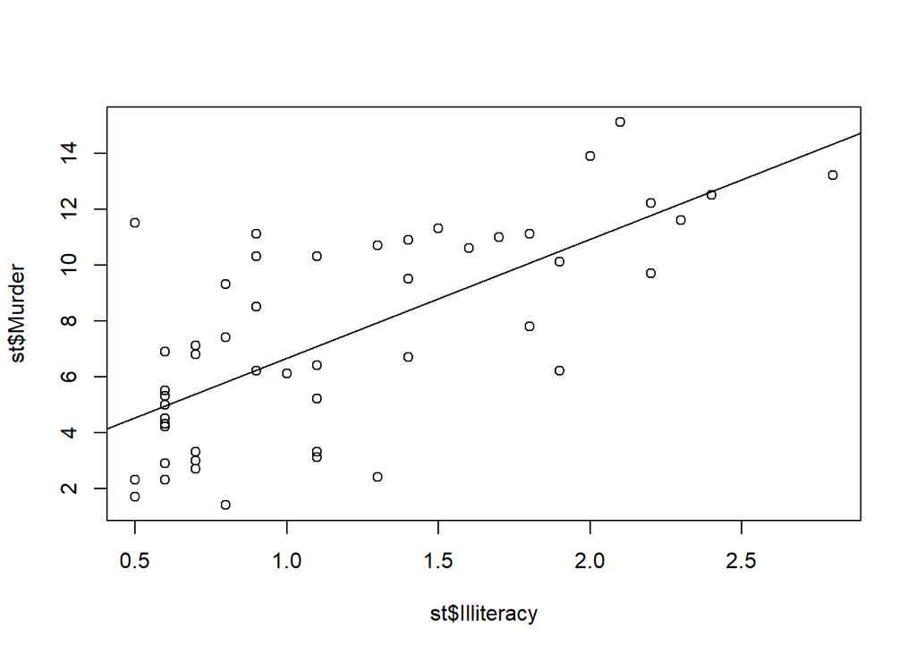

```r
plot(st$Murder~st$Illiteracy, data=st)
abline(coef(reg.simple))
```

회귀모형 적합성확인을 위해 F-검정을 실시한 결과, 유의확률이 유의수준 0.05보다 현저히 낮아 회귀식이 상당히 의미가 있음 R-Squared 값을 통해 49.4%로 murder의 변동은 illiteracy에 의해 49.4% 설명됨 추정 회귀계수의 유의확률이 0.05보다 낮아 귀무가설(회귀계수=0)을 기각 추정 회귀식:Murder=2.396776+4.257457*Illiteracy 추정 회귀식으로부터 Illiteracy가 1단위 증가할 때 Murder는 4.257457만큼 증가하고 이는 통계적으로 유의하다.

```
회귀분석 기본가정 검토 : 오차항의 독립성, 오차항의 정규성, 오차항의 등분산성
(1) 오차항의 독립성
```

```r
#install.packages('car')
library(car)
durbinWatsonTest(reg.simple)
```

```
##  lag Autocorrelation D-W Statistic p-value
##    1      -0.2193992      2.385641   0.134
##  Alternative hypothesis: rho != 0
```

```
H~0~:오차항이 독립성을 만족한다.
H~1~:오차항이 독립서을 만족하지 않는다.
2에 가까울수록 독립 (독립성만족)
D-W 통계량이 2.385641이고 p-value 값이 0.05를 넘으므로 귀무가설 채택함 (오차항의 독립성 만족)

(2) 오차항의 정규성
```

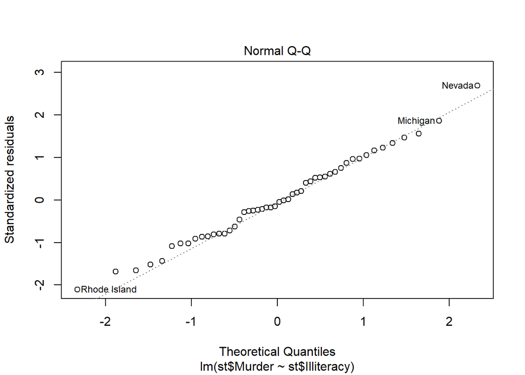

```r
plot(reg.simple, 2)
```

(3) 오차항의 등분산성: 오차항의 분산이 동일

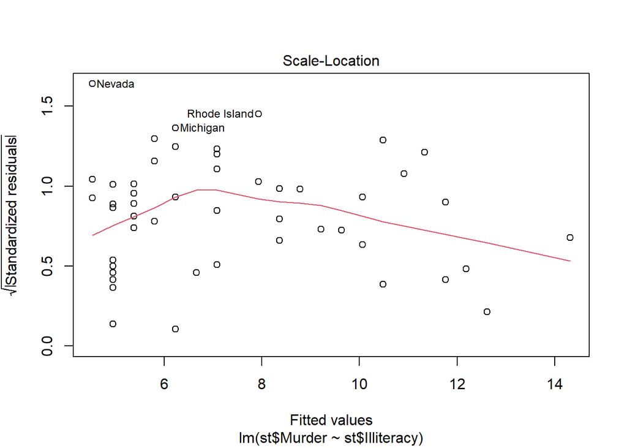

```r
plot(reg.simple, 3)
```

```r
#단순선형회귀분석
reg.simple <- lm(st$Murder~st$Illiteracy, data=st)
summary(reg.simple)
```

```
##
## Call:
## lm(formula = st$Murder ~ st$Illiteracy, data = st)
##
## Residuals:
##     Min      1Q  Median      3Q     Max
## -5.5315 -2.0602 -0.2503  1.6916  6.9745
##
## Coefficients:
##               Estimate Std. Error t value Pr(>|t|)
## (Intercept)     2.3968     0.8184   2.928   0.0052 **
## st$Illiteracy   4.2575     0.6217   6.848 1.26e-08 ***
## ---
## Signif. codes:  0 '***' 0.001 '**' 0.01 '*' 0.05 '.' 0.1 ' ' 1
##
## Residual standard error: 2.653 on 48 degrees of freedom
## Multiple R-squared:  0.4942, Adjusted R-squared:  0.4836
## F-statistic: 46.89 on 1 and 48 DF,  p-value: 1.258e-08
```

```r
summary(reg.simple)$coefficients
```

```
##               Estimate Std. Error  t value     Pr(>|t|)
## (Intercept)   2.396776  0.8184449 2.928451 5.196814e-03
## st$Illiteracy 4.257457  0.6217133 6.847942 1.257912e-08
```

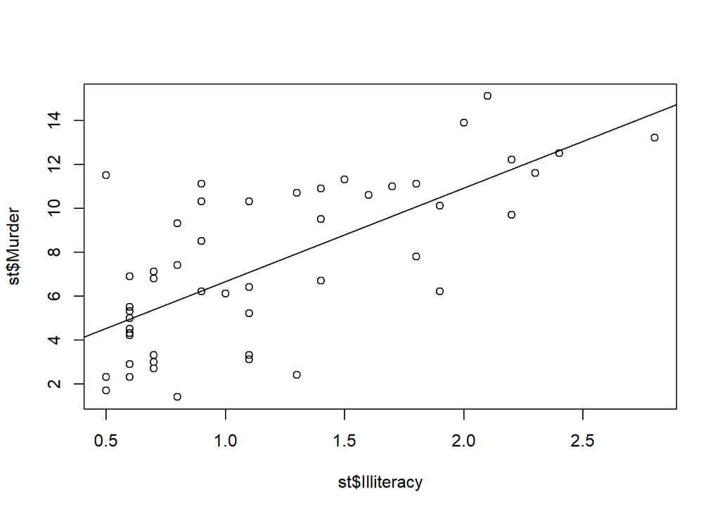

```r
plot(st$Murder~st$Illiteracy, data=st)
abline(coef(reg.simple))
```

#### **분석 2.다중회귀분석 시도**

회귀모형 적합성확인을 위해 F-검정을 실시한 결과, 유의확률이 유의수준 0.05보다 현저히 낮아 회귀식이 상당히 의미가 있음

추정 회귀식:Life Exp= 71.03 + 5.014e-05Population -3.001e-01Murder + 4.658e-02Hs-Grad -5.943e-03Frost

```r
st <- as.data.frame(state.x77)
lm <- lm(formula=st$`Life Exp`~., data=st)
summary(lm)
```

```
##
## Call:
## lm(formula = st$`Life Exp` ~ ., data = st)
##
## Residuals:
##      Min       1Q   Median       3Q      Max
## -1.48895 -0.51232 -0.02747  0.57002  1.49447
##
## Coefficients:
##               Estimate Std. Error t value Pr(>|t|)
## (Intercept)  7.094e+01  1.748e+00  40.586  < 2e-16 ***
## Population   5.180e-05  2.919e-05   1.775   0.0832 .
## Income      -2.180e-05  2.444e-04  -0.089   0.9293
## Illiteracy   3.382e-02  3.663e-01   0.092   0.9269
## Murder      -3.011e-01  4.662e-02  -6.459 8.68e-08 ***
## `HS Grad`    4.893e-02  2.332e-02   2.098   0.0420 *
## Frost       -5.735e-03  3.143e-03  -1.825   0.0752 .
## Area        -7.383e-08  1.668e-06  -0.044   0.9649
## ---
## Signif. codes:  0 '***' 0.001 '**' 0.01 '*' 0.05 '.' 0.1 ' ' 1
##
## Residual standard error: 0.7448 on 42 degrees of freedom
## Multiple R-squared:  0.7362, Adjusted R-squared:  0.6922
## F-statistic: 16.74 on 7 and 42 DF,  p-value: 2.534e-10
```

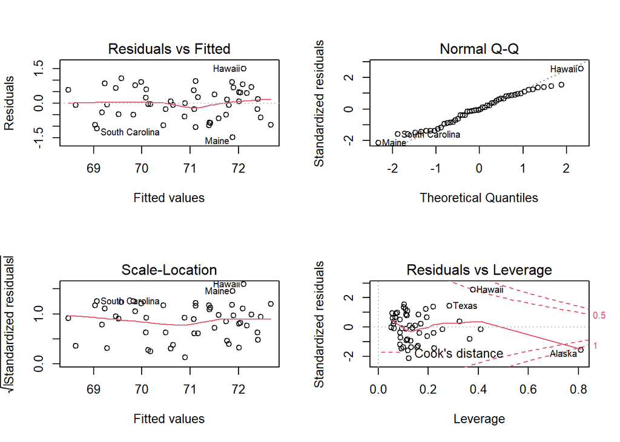

```r
par(mfrow=c(2,2))
plot(lm)
```

```r
# step(), 단계별 선택법
step_lm <- step(lm, direction = 'both')
```

```
## Start:  AIC=-22.18
## st$`Life Exp` ~ Population + Income + Illiteracy + Murder + `HS Grad` +
##     Frost + Area
##
##              Df Sum of Sq    RSS     AIC
## - Area        1    0.0011 23.298 -24.182
## - Income      1    0.0044 23.302 -24.175
## - Illiteracy  1    0.0047 23.302 -24.174
## <none>                    23.297 -22.185
## - Population  1    1.7472 25.044 -20.569
## - Frost       1    1.8466 25.144 -20.371
## - `HS Grad`   1    2.4413 25.738 -19.202
## - Murder      1   23.1411 46.438  10.305
##
## Step:  AIC=-24.18
## st$`Life Exp` ~ Population + Income + Illiteracy + Murder + `HS Grad` +
##     Frost
##
##              Df Sum of Sq    RSS     AIC
## - Illiteracy  1    0.0038 23.302 -26.174
## - Income      1    0.0059 23.304 -26.170
## <none>                    23.298 -24.182
## - Population  1    1.7599 25.058 -22.541
## + Area        1    0.0011 23.297 -22.185
## - Frost       1    2.0488 25.347 -21.968
## - `HS Grad`   1    2.9804 26.279 -20.163
## - Murder      1   26.2721 49.570  11.569
##
## Step:  AIC=-26.17
## st$`Life Exp` ~ Population + Income + Murder + `HS Grad` + Frost
##
##              Df Sum of Sq    RSS     AIC
## - Income      1     0.006 23.308 -28.161
## <none>                    23.302 -26.174
## - Population  1     1.887 25.189 -24.280
## + Illiteracy  1     0.004 23.298 -24.182
## + Area        1     0.000 23.302 -24.174
## - Frost       1     3.037 26.339 -22.048
## - `HS Grad`   1     3.495 26.797 -21.187
## - Murder      1    34.739 58.041  17.456
##
## Step:  AIC=-28.16
## st$`Life Exp` ~ Population + Murder + `HS Grad` + Frost
##
##              Df Sum of Sq    RSS     AIC
## <none>                    23.308 -28.161
## + Income      1     0.006 23.302 -26.174
## + Illiteracy  1     0.004 23.304 -26.170
## + Area        1     0.001 23.307 -26.163
## - Population  1     2.064 25.372 -25.920
## - Frost       1     3.122 26.430 -23.877
## - `HS Grad`   1     5.112 28.420 -20.246
## - Murder      1    34.816 58.124  15.528
```

```r
summary(step_lm)
```

```
##
## Call:
## lm(formula = st$`Life Exp` ~ Population + Murder + `HS Grad` +
##     Frost, data = st)
##
## Residuals:
##      Min       1Q   Median       3Q      Max
## -1.47095 -0.53464 -0.03701  0.57621  1.50683
##
## Coefficients:
##               Estimate Std. Error t value Pr(>|t|)
## (Intercept)  7.103e+01  9.529e-01  74.542  < 2e-16 ***
## Population   5.014e-05  2.512e-05   1.996  0.05201 .
## Murder      -3.001e-01  3.661e-02  -8.199 1.77e-10 ***
## `HS Grad`    4.658e-02  1.483e-02   3.142  0.00297 **
## Frost       -5.943e-03  2.421e-03  -2.455  0.01802 *
## ---
## Signif. codes:  0 '***' 0.001 '**' 0.01 '*' 0.05 '.' 0.1 ' ' 1
##
## Residual standard error: 0.7197 on 45 degrees of freedom
## Multiple R-squared:  0.736,  Adjusted R-squared:  0.7126
## F-statistic: 31.37 on 4 and 45 DF,  p-value: 1.696e-12
```

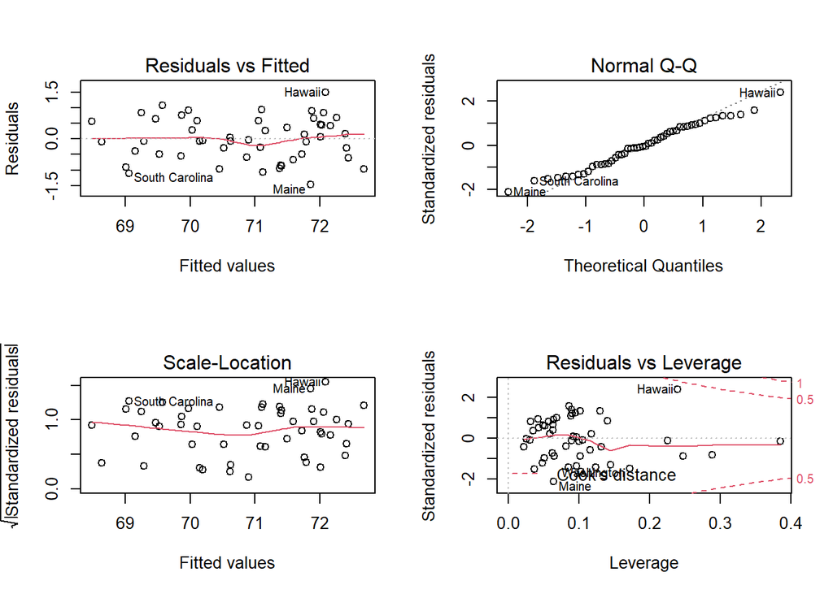

```r
par(mfrow=c(2,2))
plot(step_lm)
```

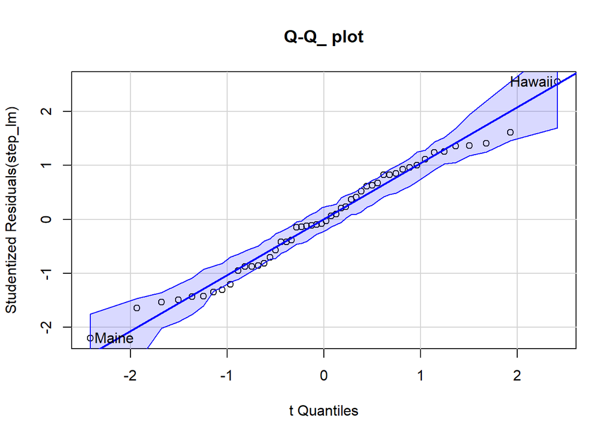

```
## Hawaii  Maine
##     11     19
```

```r
par(mfrow=c(1,1))

# 정규성 검정
# install.packages("car")
library(car)
qqPlot(step_lm,labels=row.names(st),id.method="identify",simulate=TRUE,main="Q-Q_ plot")
```

```r
# 독립성 검정
durbinWatsonTest(step_lm)
```

```
##  lag Autocorrelation D-W Statistic p-value
##    1      0.02867262      1.913997   0.738
##  Alternative hypothesis: rho != 0
```

```r
# 다중공선성 확인
vif(step_lm)
```

```
## Population     Murder  `HS Grad`      Frost
##   1.189835   1.727844   1.356791   1.498077
```

```r
sqrt(vif(step_lm))>2
```

```
## Population     Murder  `HS Grad`      Frost
##      FALSE      FALSE      FALSE      FALSE
```

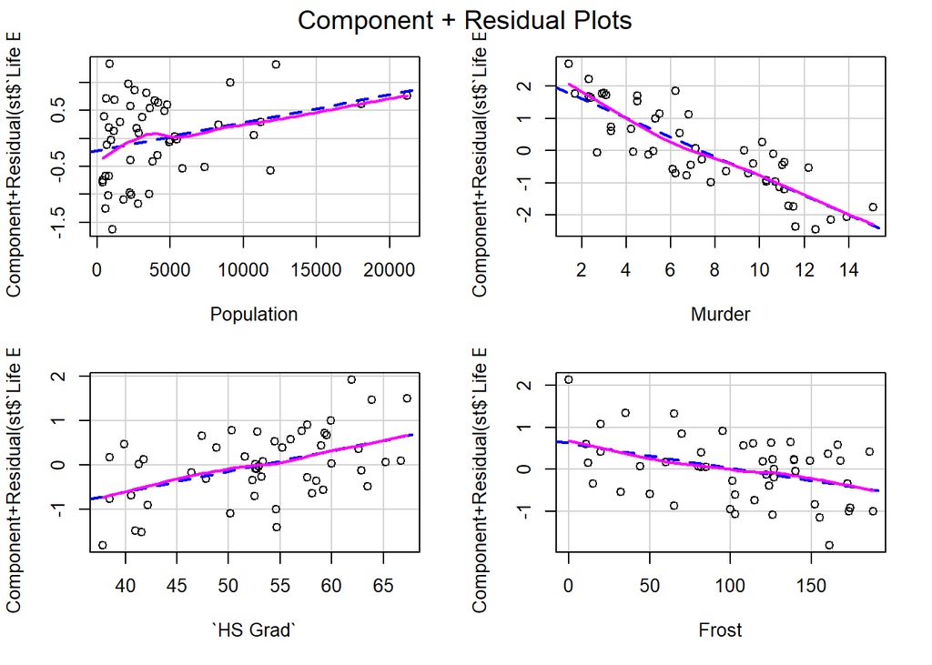

```r
crPlots(step_lm)
```

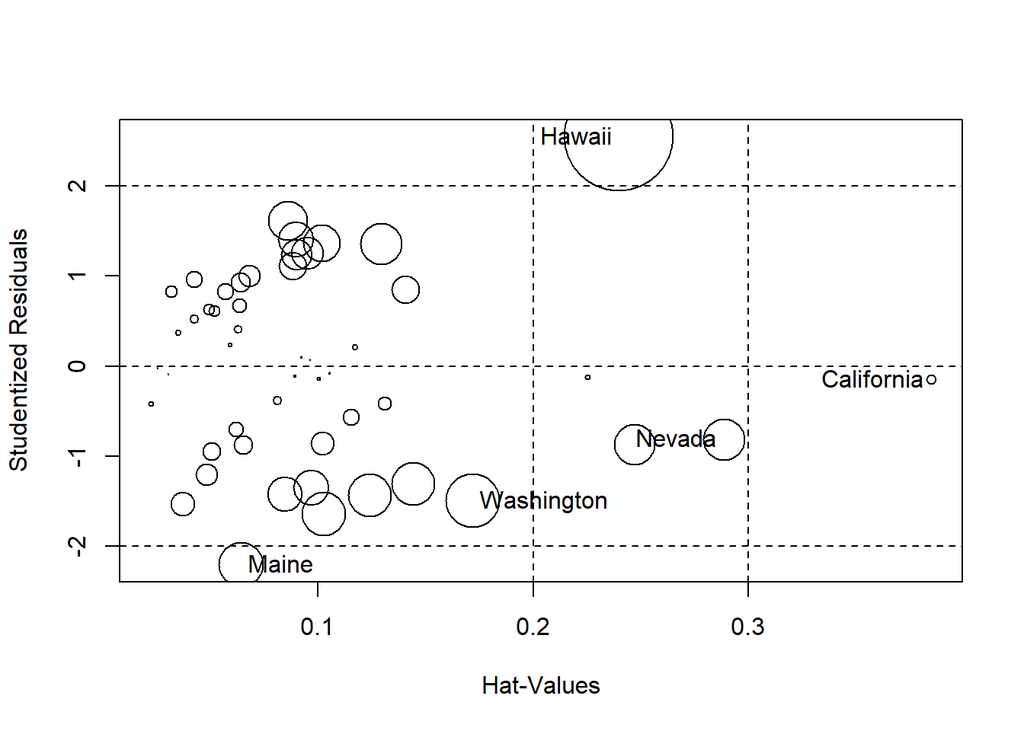

```
##               StudRes        Hat       CookD
## California -0.1500614 0.38475924 0.002879053
## Hawaii      2.5430162 0.23979244 0.363778638
## Maine      -2.2012995 0.06424817 0.061301962
## Nevada     -0.8120831 0.28860921 0.053917754
## Washington -1.4895722 0.17168830 0.089555784
```

```r
influencePlot(step_lm)
```

## **문제 4: 생활속의 통계학 연습문제 풀이: 확률분포 문제 풀이**

- 생활속의 통계학 제 5 장, 제 6 장의 예제/연습문제 중에서 각각 2문제(총 4문제)를 골라 R 코드로 풀어보시오.

### **1. 제5장 - 29번**

한 중간 판매업자가 50개의 상품을 수입하였다. 이들 수입 상품 중 5개의 결함이 있으나 판매업자는 몇 개의 상품에 결함이 있는지 모른다. 판매업자는 수입 상품 중에서 10개를 임의로 뽑아 결함이 있는지 조사하기로 하였다. 이때, 조사한 상품 중에서 결함이 있는 상품이 2개 이하이면 수입을 허용하기로 하였다. 이 판매업자가 수입된 상품을 허용할 확률을 구하라.

```r
fact <- function (n) {
    a = c(1)
    if (n>0){
        for (i in 1:n){
            a[i+1]=a[i]*i
        }
    }
    return(a[n+1])
}
```

```r
comb <- function (n, r) {
    return (fact(n) / fact(r) / fact(n - r))
}
```

```r
(comb(45,10)*comb(5,0)+comb(45,9)*comb(5,1)+comb(45,8)*comb(5,2))/comb(50,10)
```

```
## [1] 0.9517397
```

### **2. 제5장 - 30번**

```
지하수 오염 실태를 조사하기 위하여 30곳에 구멍을 뚫어 수질을 조사하였다. 그 결과 19곳은         오염이 매우 심각하였고, 6곳은약간 오염되었다고 보고하였다. 그러나 채취한 지하수 병들이 섞여       있어 어느 지역의 지하수가 깨끗한지 모른다. 이런 상황에서 5곳을 선정하였을 때, 다음을 구하라.
(1) 오염 정도에 따른 확률분포

심각한 지역=x, 약간 오염된 지역=y, 정상인 지역=z
확률 분포 = (19 C x)*(6 C y)*(5 C z)/(30 C 5)

(2) 선정된 5곳 중에서 매우 심각하게 오염된 지역이 3곳, 약간 오염된 지역이 1곳일 확률
```

```r
comb(19,3)*comb(6,1)*comb(5,1)/comb(30,5)
```

```
## [1] 0.2039914
```

```
(3) 선정된 5곳 중에서 적어도 4곳이 심각하게 오염되었을 확률
```

```r
(comb(19,4)*comb(11,1)+comb(19,5))/comb(30,5)
```

```
## [1] 0.380784
```

### **3. 제6장 - 17번**

```
X~*N*(10, 9)에 대하여 다음을 만족하는 x~0~을 구하라
(1) P(X \leq x~0~) = 0.9986
```

```r
qnorm(0.9986, 10, sqrt(9))
```

```
## [1] 18.96665
```

```
(2) P(X \leq x~0~) = 0.0154
```

```r
qnorm(0.0154, 10, sqrt(9))
```

```
## [1] 3.521059
```

```
(3) P(10 \leq X \leq x~0~) = 0.3554
```

```r
qnorm(0.3554+0.5, 10, sqrt(9))
```

```
## [1] 13.17963
```

```
(4) P(-x~0~ \leq X \leq x~0~) = 0.9030
```

```r
qnorm((0.9030+1)/2, 10, sqrt(9))
```

```
## [1] 14.97872
```

```
(5) P(-x~0~ \leq X \leq x~0~) = 0.2052
```

```r
qnorm((0.2052+1)/2, 10, sqrt(9))
```

```
## [1] 10.78025
```

```
(6) P(X \geq x~0~) = 0.6915
```

```r
qnorm(0.6915, 10, sqrt(9), lower.tail = F)
```

```
## [1] 8.49968
```

### **4. 제6장 - 21번**

```
고교 3학년 학생 1,000명에게 실시한 모의고사 국어점수 X와 수학점수 Y는 각각 X~*N*(75, 9),         Y~*N*(68, 16)인 정규분포를 따르고, 이 두 성적ㄹ은 서로 독립이라고 한다. 물음에 답하라
```

```r
xmu <- 75
xvar <- 9
ymu <- 68
yvar <- 16
```

```
(1) 국어점수가 82점 이상일 확률
```

```r
pnorm(82, xmu, sqrt(xvar), lower.tail = F)
```

```
## [1] 0.009815329
```

```
(2) 두 과목 점수의 합이 130점 이상, 150점 이하에 해당하는 학생 수
```

```r
xy_mu=xmu+ymu
xy_var=xvar+yvar
pnorm(c(130, 150), xy_mu, sqrt(xy_var))
```

```
## [1] 0.004661188 0.919243341
```

```r
a <- {pnorm(150, xy_mu, sqrt(xy_var))-pnorm(130, xy_mu, sqrt(xy_var))}*1000
cat('130점과 150점 사이에 있는 학생 수는', ceiling(a), '명입니다.')
```

```
## 130점과 150점 사이에 있는 학생 수는 915 명입니다.
```

```
(3) 각 과목에서 상위 5% 안에 들어가기 위한 최소 점수
```

```r
kor=qnorm(0.05, xmu, sqrt(xvar), lower.tail = F)
kor
```

```
## [1] 79.93456
```

```r
math=qnorm(0.05, ymu, sqrt(yvar), lower.tail = F)
math
```

```
## [1] 74.57941
```

```r
cat('상위 5%가 되는 최소점수는 국어', ':', ceiling(kor), '점,', '수학', ":", ceiling(math),'점입니다.')
```

```
## 상위 5%가 되는 최소점수는 국어 : 80 점, 수학 : 75 점입니다.
```

## **문제 5: 생활속의 통계학 연습문제 풀이: 통계적 추론 문제 풀이**

- 생활속의 통계학 제 7 장, 제 8 장의 예제/연습문제 중에서 각각 2문제(총 4문제)를 골라 R 코드로 풀어보시오.

### **1. 제7장 - 3번**

```
\mu = 50이고 모표준편차가 다음과 같은 모집단으로부터 크기 25인 확률표본을 선정할 때,            표본평균이 49와 52 사이일 확률을 구하라.
```

```r
n <- 25
mu <- 50
a <- c(49, 52)
```

```
(1) \sigma = 4
```

```r
sigma1=4
sdx1 <- sigma1/sqrt(n)
sdx1
```

```
## [1] 0.8
```

```r
pnorm(a,mu, sdx1)
```

```
## [1] 0.1056498 0.9937903
```

```r
pnorm(a[2], mu, sdx1)-pnorm(a[1], mu, sdx1)
```

```
## [1] 0.8881406
```

```
(2) \sigma = 9
```

```r
sigma2=9
sdx2 <- sigma2/sqrt(n)
pnorm(c(49, 52), 50, sdx2)
```

```
## [1] 0.2892574 0.8667397
```

```r
pnorm(a[2], mu, sdx2)-pnorm(a[1], mu, sdx2)
```

```
## [1] 0.5774824
```

```
(3) \sigma = 12
```

```r
sigma3=12
sdx3 <- sigma3/sqrt(n)
pnorm(c(49, 52), 50, sdx3)
```

```
## [1] 0.3384611 0.7976716
```

```r
pnorm(a[2], mu, sdx3)-pnorm(a[1], mu, sdx3)
```

```
## [1] 0.4592105
```

### **2. 제7장 - 8번**

우리나라 20세 이상 성인 남자의 혈중 콜레스테롤 수치는 평규 = 198, 분산 ^2 = 36인 정규분포를 따른다고 가정하자. 물음에 답하라 (단, 단위는 mg/dL이다.)

```r
mu=198
var=36
```

```
(1) 임의로 1명을 선정하였을 때, 이 사람의 혈압이 196과 200 사이일 확률
```

```r
pnorm(c(196, 200), mu, sqrt(var))
```

```
## [1] 0.3694413 0.6305587
```

```r
pnorm(200, mu, sqrt(var))-pnorm(196, mu, sqrt(var))
```

```
## [1] 0.2611173
```

```
(2) 100명을 임의로 선정하여 표본을 만들 때, 표본평균 \overline{x}의 표본분포를 구하라
```

```r
n=100
sdx=sqrt(var)/sqrt(n)
sdx
```

```
## [1] 0.6
```

```r
cat('x~N(',mu,',', sdx, ')')
```

```
## x~N( 198 , 0.6 )
```

```
(3) 표본평균이 196과 200 사이일 확률
```

```r
pnorm(c(196, 200), mu, sdx)
```

```
## [1] 0.0004290603 0.9995709397
```

```r
pnorm(200, mu, sdx)-pnorm(196, mu, sdx)
```

```
## [1] 0.9991419
```

```
(4) 표본평균이 \mu\pm$$frac{\sigma}{5}$$ 사이일 확률
```

```r
interval = mu + c(-(sqrt(var)/5), sqrt(var)/5)
interval[1]
```

```
## [1] 196.8
```

```r
pnorm(interval[2], mu, sdx)-pnorm(interval[1], mu, sdx)
```

```
## [1] 0.9544997
```

### **3. 제8장 - 2번**

모분산 4인 정규모집단의 모평균에 대한 95% 신뢰도를 갖는 구간을 추정하기 위하여 다음과 같은 크기의 표본을 선정한다. 이때 오차한계를 구하라.

```r
#se=2/sqrt(n)
var=4
se <- function(x) sqrt(var)/sqrt(n)
```

```
(1) *n* = 50
```

```r
n=50
se1 <- se(1)
se1
```

```
## [1] 0.2828427
```

```
(2) *n* = 100
```

```r
n=100
se2 <- se(2)
se2
```

```
## [1] 0.2
```

```
(3) *n* = 200
```

```r
n=200
se3 <- se(3)
se3
```

```
## [1] 0.1414214
```

```
(4) *n* = 500
```

```r
n=500
se4<- se(4)
se4
```

```
## [1] 0.08944272
```

### **4. 제8장 - 7번**

어느 회사에서 생산하는 비누의 무제는 분산이 \sigma^2 = 5.4g인 정규분포를 따른다고 한다. 50개의 비누를 임의로 추출하였을 때, 그 평균 무게의 값은 \overline{x} = 95.1g 이었다. 이 회사에서 생산하는 비누의 평균 무게에 대한 95% 신뢰구간을 구하라.

```r
var <- 5.4
n <- 50
mu <- 95.1
sigma <- sqrt(var/n)
CI <- mu + c(-1.96, 1.96)*sigma
CI
```

```
## [1] 94.45588 95.74412
```

```r
cat('95% CI =', CI[1], '~', CI[2])
```

```
## 95% CI = 94.45588 ~ 95.74412
```